# US COVID-19 Data Tracker Design Report

> **Name:** Yumeng Li  
> **UIN:** 674513639

## Section 1: Dataset description

### Dataset 1: COVID-19 Vaccinations in the United States, Jurisdiction

Overall US COVID-19 Vaccine deliveries and administration data at national and jurisdiction level.

- **Date**: Date
- **Location**: State/ Territory/ Federal Entity
- **Administered_Dose1_Pop_Pct**: Percent of population with at least one dose based on the jurisdiction where recipient lives
- **Series_Complete_Pop_Pct**: Percent of people who are fully vaccinated (have second dose of a two-dose vaccine or one dose of a single-dose vaccine) based on the jurisdiction where recipient lives

### Dataset 2: COVID-19 Vaccinations in the United States, County

Overall US COVID-19 Vaccine administration and vaccine equity data at county level.

- **Date**: Date data are reported on CDC COVID Data Tracker
- **FIPS**: Federal Information Processing Standard State Code
- **Recip_State**: Recipient State
- **Recip_County**: County of residence
- **Administered_Dose1_Pop_Pct**: Percent of Total Pop with at least one Dose by State of Residence
- **Series_Complete_Pop_Pct**: Percent of people who are fully vaccinated (have second dose of a two-dose vaccine or one dose of a single-dose vaccine) based on the jurisdiction and county where recipient lives

### Dataset 3:United States COVID-19 County Level of Community Transmission as Originally Posted

- **report_date**: Date county level of community transmission indicator reported on COVID Data Tracker
- **state_name**: State
- **county_name**: County
- **cases_per_100K_7_day_count_change**: Total number of new cases per 100,000 persons within the last 7 days. When the total new case rate metric ("cases_per_100K_7_day_count_change") is greater than zero and less than 10, this metric is set to "suppressed".
- **percent_test_results_reported_positive_last_7_days**: Percentage of positive diagnostic and screening nucleic acid amplification tests (NAAT) during the last 7 days

## Section 2: Question of interest

1. The goal of the web app is to allow users to check the vaccination status on both broader view (state level) and detailed view (county level). The users will have knowledge of vaccination distribution in the US.
1. It also allows users to see the trend of daily positivity percentage and new cases in a certain time interval.
1. By using this web app, users could get a general relationship between daily cases and vaccination status to check the effect of the vaccines on reducing transmission of the virus

## Section 3: Testing of the web app

```python
from IPython.display import Image
from IPython.core.display import HTML
```

- **Test Figure 1 with different datasets**

  The original dash app is created by using dataset before 11/24/21. I tested it by subsituting all dataset to the latest edition. The newest date of this edition is 12/13/21. Below are two screenshots from each edition dataset. My dash app works well in both datasets.

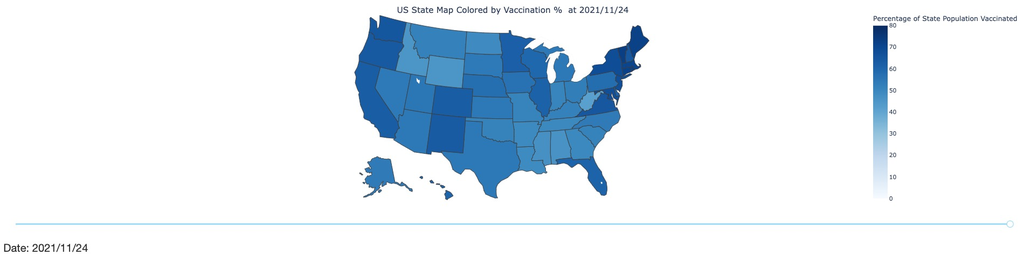

```python
Image(r'/Users/mengmengmeng/Desktop/stat430/final/1639514822958.jpg')
```

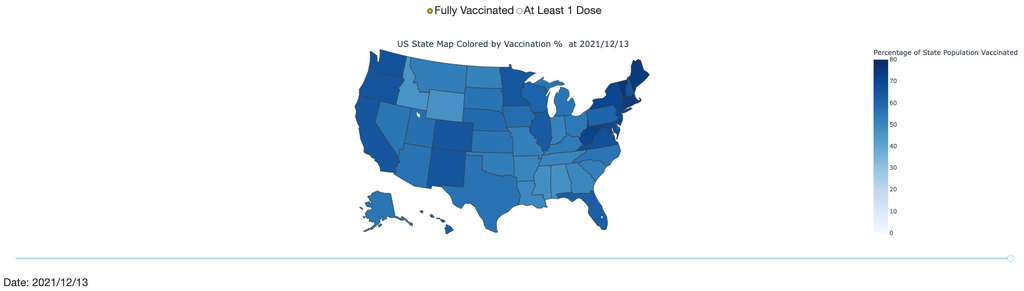

```python
Image(r'/Users/mengmengmeng/Desktop/stat430/final/1639514708947.jpg')
```

- **Test Figure 2 with CDC Website:**

  Below are two figures showing % of fully vaccinated in IL. The first figure is created by my dash app. The second one is from CDC website. (https://covid.cdc.gov/covid-data-tracker/#county-view&list_select_state=Illinois&list_select_map_data_parent=Vaccinations&map-metrics-cv-vaccinations=Series_Complete_Pop_Pct) Compare two figures with the darkest blocks and lightest blocks. They are approximatly in the same locations, which means my dash app is correct in creating Figure 2.

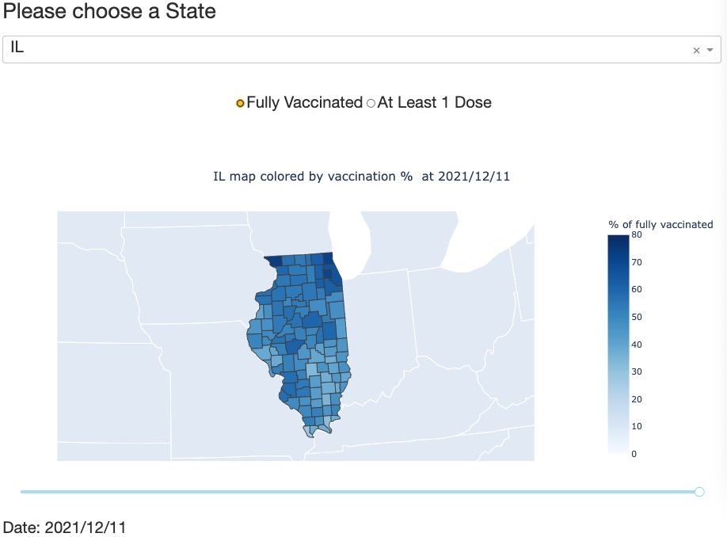

```python
Image(r'/Users/mengmengmeng/Desktop/stat430/final/1639512925495.jpg',width=600, height=600)
```

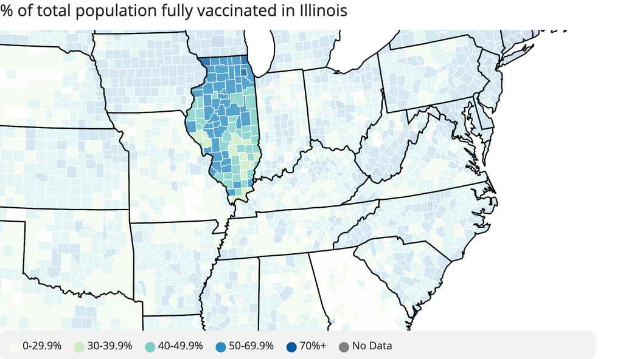

```python
Image(r'/Users/mengmengmeng/Desktop/stat430/final/Illinois_%_of_total_population_fully_vaccinated.png',width=600, height=600)
```

- **Test Figure 3 with Jupyter Notebook:** I also tested Figure 3 with Jupyter notebook. The first figure below is a screenshot of Figure 3 from my dash app. The second figure is from Jupyter notebook with same time interval and same location. These two figures are the same.

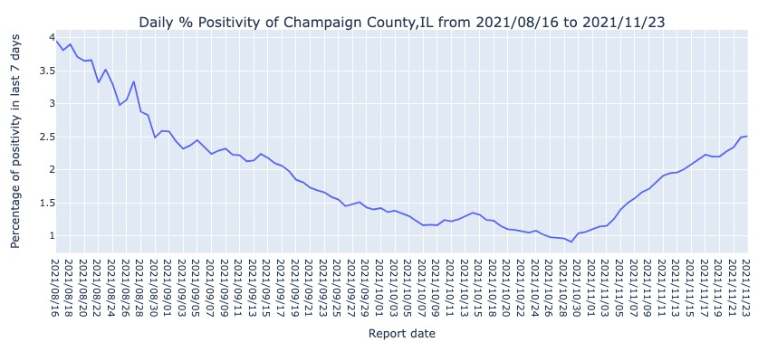

```python
Image(r'/Users/mengmengmeng/Desktop/stat430/final/1639515014380.jpg',width=600, height=600)
```

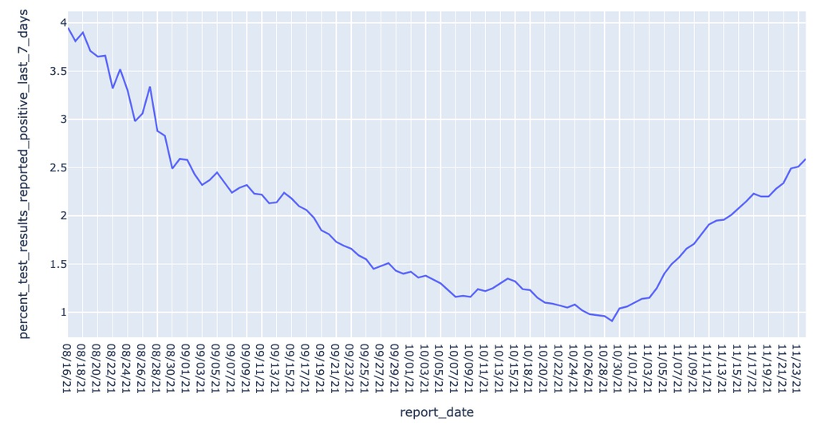

```python
Image(r'/Users/mengmengmeng/Desktop/stat430/final/1639515184699.jpg',width=600, height=600)
```

## Section 4: Conclusion & discussion

### What did you do well?

- All the graphs are displayed and updated correctly.
- There are no errors complained about both in the terminal and the dash app.
- All hover labels are displayed clearly and are easy to read.
- Made titles of plot adjust to state and county selection
- It meets the goal of designing the web app, which contains all the information and easy to read.

### What could be improved?

- In graph 1, hover label is not adjusted to "fully vaccinated" and "at least one dose" selection.
- Should change all date slider in order to see all possible selections on the slider bar.

### If someone is to continue working on your project, what should they tackle next?

- In graph 1, add the type of vaccine: Janssen, Moderna, Pfizer. In this way, the users could see the different distribution of each vaccine across the US states.
- Could display all four plots based on different age groups: 12 years old +, 18 years old + and 65 years old +.
- Combine dataset 2 and 3, add community transmission level from dataset 3 to graph 2.